# Презентация лаборотарной работы 6

Соловьев Богдан Михайлович

Российский университет дружбы народов

2026-05-02

# Информация

# Цель работы

Реализовать модель эпидемии SIR (Susceptible–Infectious–Recovered) с использованием сетей Петри.

# Задание

Создать рабочий каталог для кода.

Установить необходимые пакеты.

Выполнить предложенный код.

Преобразовать код в литературный стиль.

Сгенерировать из литературного кода:

чистый код;

jupyter notebook;

документацию в формате Quarto.

Выполнить код из jupyter notebook.

Интегрировать документацию в формате Quarto в отчёт.

Добавить в код в литературном стиле вычисление для набора параметров.

Сгенерировать из литературного кода с параметрами:

чистый код;

jupyter notebook;

документацию в формате Quarto.

Выполнить код из jupyter notebook с параметрами.

Интегрировать документацию с параметрами в формате Quarto в отчёт.

# Теоретическое введение

Модель описывает переходы между тремя состояниями:

S (восприимчивые) — могут заразиться;

I (инфицированные) — заражают других и выздоравливают;

R (выздоровевшие / с иммунитетом) — больше не участвуют в эпидемии.

Сеть Петри содержит два перехода:

infection:

(скорость β);

recovery:

(скорость γ).

# Выполнение лабораторной работы

Создаю пространство для выполнения лабораторной. Для этого создаю setup_report, потом add_packages и tangle. (Ничего нового),

поэтому перейдём сразу к модели. Создаю в папке src саму модель, которой буду пользоваться дальше. Теперь запускаю код, который

выполоняет базовый прогон модели с b=0,3 y=0,1. При этом запускается две симуляции:

детерминированную (решение ОДУ) — даёт плавную усреднённую динамику;

стохастическую (алгоритм Гиллеспи) — учитывает случайные флуктуации.

Сохраняет результаты в CSV‑файлы и строит графики S(t), I(t), R(t) есть ли дедлок(рис. 1).

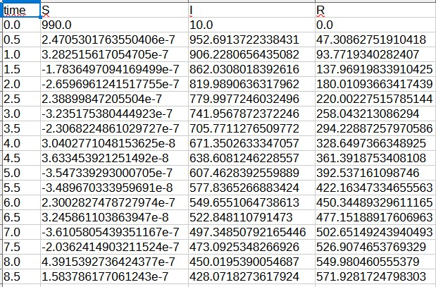

Рисунок 1: Пример csv файла выходного

Так же этот скрипт выводит графики S(t)m I(t), R(t) (рис. 2).

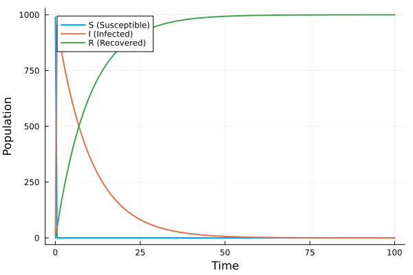

Рисунок 2: Детерминистический график динамики SIR

Стохастический график может иметь шумы и, возможно, немного отличаться по времени пика и амплитуде – это демонстрирует влияние случайности. (рис. 3).

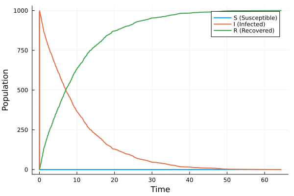

Рисунок 3: Стохастический график динамики SIR

Далее запускается исследование чувствительности системы к параметру b

β_range = 0.1 : 0.05 : 0.8 (всего 15 значений)

γ_fixed = 0.1

tmax = 100.0

(рис. 4)

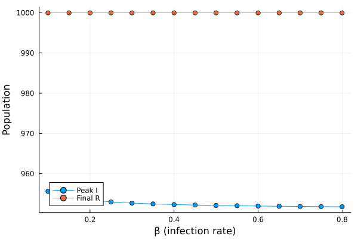

Рисунок 4: b

График чувствительности позволяет количественно оценить, как изменение заразности β влияет на тяжесть эпидемии (пик I). Это важно для принятия решений (например, меры по снижению β).

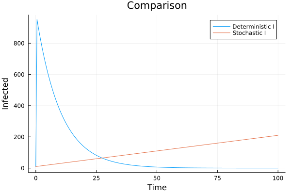

Рисунок 5: Сравнение

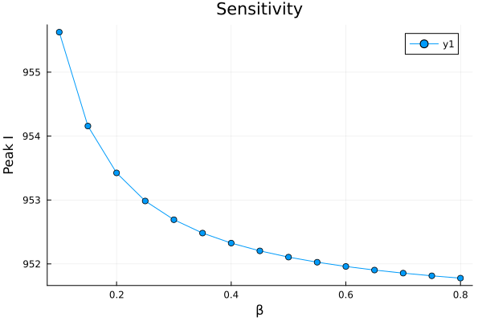

# Выводы

Я реализовал модели эпидемии SIR

# Список литературы